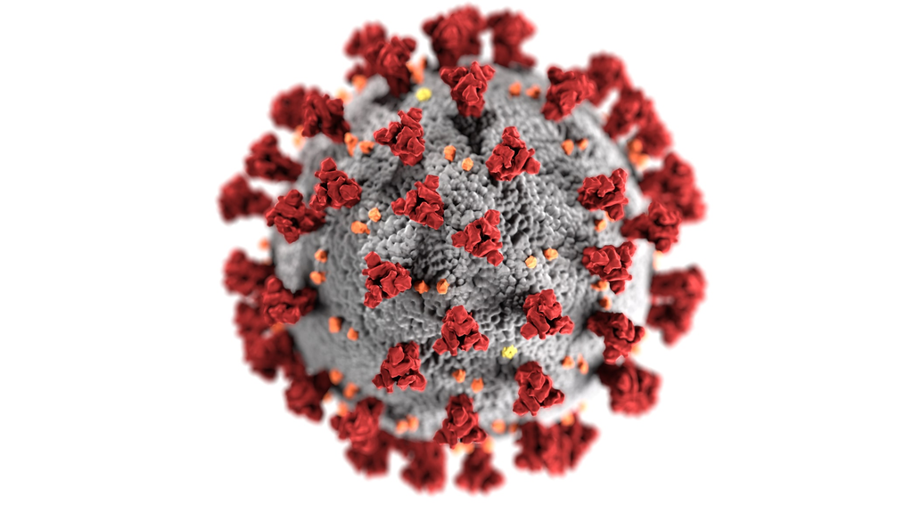

# **Analysis of the Impacts of COVID-19 on Global Populations**

**Author**: Willian Botelho

**Date**: 05/19/2024

### Introduction

This academic project conducts an analysis of COVID-19 data, which includes daily records of confirmed cases and virus-related deaths. The data were collected and consolidated from various global sources and are essential for understanding the impacts of the pandemic, especially in countries with populations larger than that of Brazil.

### Data Description

The datasets used in this study include several key variables, such as:

- **FIPS** (Federal Information Processing Standards): A code used in the United States to uniquely identify counties.
- **Admin2**: The name of the county, applicable only in the United States.
- **Province_State**: The name of the province or state.
- **Country_Region**: The name of the country or region, as officially designated by the U.S. Department of State.
- **Last Update**: The date and time of the last data update, in MM/DD/YYYY HH:mm:ss UTC format.
- **Lat and Long_**: Geographic coordinates, with representative centroids for each location.
- **Confirmed**: Number of confirmed and probable cases.
- **Deaths**: Number of confirmed and probable deaths.

### Study Objectives

The primary objective of this study is to assess the impacts of COVID-19 on countries with populations larger than Brazil, using consolidated data that includes key variables for effective analysis. This work is part of the Master’s in Data Science program at the University of Colorado Boulder and aims to deepen understanding of the pandemic, without intending to influence public health policies.

### Data Sources

The data for this study were extracted from the following GitHub repositories:

- Daily data on confirmed cases: [COVID-19 Time Series Data - Confirmed Cases](https://github.com/CSSEGISandData/COVID-19/blob/master/csse_covid_19_data/csse_covid_19_time_series/time_series_covid19_confirmed_global.csv)
- Daily data on deaths: [COVID-19 Time Series Data - Deaths](https://github.com/CSSEGISandData/COVID-19/blob/master/csse_covid_19_data/csse_covid_19_time_series/time_series_covid19_deaths_global.csv)
- Country population reference: [COVID-19 UID ISO FIPS LookUp Table](https://github.com/CSSEGISandData/COVID-19/blob/master/csse_covid_19_data/UID_ISO_FIPS_LookUp_Table.csv)

### Methodology

This project utilizes the SEMMA methodology to analyze COVID-19 data, focusing on the following steps:

1. **Sample**: Selection of countries with populations greater than Brazil to ensure a representative demographic scale.
2. **Explore**: Examination of data through visualizations and descriptive statistics to identify trends and anomalies.
3. **Modify**: Data wrangling to standardize datasets for accurate analysis, including handling missing values and data inconsistencies.
4. **Model**: Application of statistical and machine learning models to estimate trends and predict future scenarios.
5. **Assess**: Evaluation of model accuracy and reliability through cross-validation and analysis of results to determine public health implications.

This study seeks not only to understand but also to systematically document the patterns of dissemination and impact of the virus, contributing to future research and interventions in global public health.

### Sample

To ensure reproducibility, we will use publicly available data from the GitHub repository as previously mentioned. Additionally, the code will include detailed comments and comprehensive documentation that will describe each step of the analytical process.

This ranges from data acquisition to the application of statistical methods and model configurations, including details of any data preprocessing or transformation.

```r
# Define URLs for confirmed cases, deaths, and demographic information of countries
confirmed_global <- "https://raw.githubusercontent.com/CSSEGISandData/COVID-19/master/csse_covid_19_data/csse_covid_19_time_series/time_series_covid19_confirmed_global.csv"
deaths_global   <- "https://raw.githubusercontent.com/CSSEGISandData/COVID-19/master/csse_covid_19_data/csse_covid_19_time_series/time_series_covid19_deaths_global.csv"
UID_FIPS_table_url = "https://raw.githubusercontent.com/CSSEGISandData/COVID-19/master/csse_covid_19_data/UID_ISO_FIPS_LookUp_Table.csv"

# Load data from the defined URLs
confirmed <- read_csv(confirmed_global)
deaths <- read_csv(deaths_global)
UID_FIPS_table <- read_csv(UID_FIPS_table_url)

# Transform the confirmed data from wide to long format,
# extracting dates and confirmed cases for each location
confirmed <- confirmed %>%
  pivot_longer(
    cols = -c(`Province/State`, `Country/Region`, Lat, Long),  # Keep these columns fixed
    names_to = "data",  # Name of the new column for dates
    values_to = "cases"  # Name of the new column for cases
  ) %>% mutate(data = mdy(data))  # Convert dates from month/day/year format to Date

# Transform the death data from wide to long format,
# similar to the confirmed data
deaths <- deaths %>%
  pivot_longer(
    cols = -c(`Province/State`, `Country/Region`, Lat, Long),
    names_to = "data",
    values_to = "deaths"
  ) %>% mutate(data = mdy(data))

# Load the demographic information table
UID_FIPS_table <- read.csv(UID_FIPS_table_url)

# Extract Brazil's population using the combined key "Brazil"
pop_brasil <- UID_FIPS_table %>%
  filter(Combined_Key == "Brazil") %>%
  pull(Population)  # Only extract the population value

# Filter countries with a population greater than or equal to Brazil's,
# excluding province or state records (country-level data)
countries_larger_than_brazil <- UID_FIPS_table %>%
  filter(Population >= pop_brasil) %>%
  filter(is.na(Province_State) | Province_State == "") %>%
  select(Country_Region, Population) %>%
  rename(Countries = "Country_Region")

# Perform a join of the confirmed and death data based on multiple keys
combined_data <- confirmed %>%
  left_join(deaths, by = c("Country/Region", "Province/State", "Lat", "Long", "data")) %>%
  select(-`Province/State`) %>%
  rename(Countries = "Country/Region")

# Filter the combined data to only include countries with a population greater than Brazil's
final_data <- combined_data %>%
  filter(Countries %in% countries_larger_than_brazil$Countries)

final_data <- final_data %>%
  filter(complete.cases(final_data)) %>%
  filter(cases > 0 & deaths > 0) %>%
  rename(date = "data")

# Display the first few lines of the final data set
head(final_data)
```

```
## # A tibble: 6 × 6
##   Countries   Lat  Long date       cases deaths
##   <chr>     <dbl> <dbl> <date>     <dbl>  <dbl>
## 1 Brazil    -14.2 -51.9 2020-03-17   321      1
## 2 Brazil    -14.2 -51.9 2020-03-18   372      3
## 3 Brazil    -14.2 -51.9 2020-03-19   621      6
## 4 Brazil    -14.2 -51.9 2020-03-20   793     11
## 5 Brazil    -14.2 -51.9 2020-03-21  1021     15
## 6 Brazil    -14.2 -51.9 2020-03-22  1546     25
```

```r
summary(final_data)
```

```
##   Countries              Lat              Long              date
##  Length:36227       Min.   :-14.23   Min.   :-100.00   Min.   :2020-01-22
##  Class :character   1st Qu.: 24.97   1st Qu.: 106.87   1st Qu.:2020-11-20
##  Mode  :character   Median : 30.62   Median : 113.55   Median :2021-08-30
##                     Mean   : 30.16   Mean   :  99.33   Mean   :2021-08-29
##                     3rd Qu.: 39.31   3rd Qu.: 117.23   3rd Qu.:2022-06-09
##                     Max.   : 47.86   Max.   : 127.76   Max.   :2023-03-09
##      cases               deaths
##  Min.   :        1   Min.   :      1
##  1st Qu.:      598   1st Qu.:      2
##  Median :     1355   Median :      6
##  Mean   :  3029075   Mean   :  46892
##  3rd Qu.:     8655   3rd Qu.:     20
##  Max.   :103802702   Max.   :1123836
```

After the transformations made in the described code, we obtain a table represented by `final_data`, which contains 36227 rows and 6 columns. This table includes all countries with a population greater than that of Brazil. The countries listed are **Brazil, China, India, Indonesia, Pakistan, US**.

### Explore and Modify

Let’s explore the data by country to understand its characteristics and try to answer some important questions, such as:

1. Are there differences in the patterns of cases and deaths among countries?
2. Do the data show any integrity issues, such as inconsistencies or gaps?
3. Are there indications of underreporting or absence of data during certain periods or in certain countries?
4. How do descriptive statistics, such as mean, standard deviation, maximum, and minimum values, compare among different countries?

```r
# Check duplicates by country and date
duplicates_by_country <- final_data %>%
  group_by(Countries, date) %>%
  summarise(Count = n(), .groups = 'drop') %>%
  filter(Count > 1)

print(unique(duplicates_by_country$Countries))
```

```
## [1] "China"
```

Data listed in the Countries column that is duplicated: **China**

Let’s check how duplicated this data is for the China dataset and then decide what to do.

```r
# Filter data for China and check for duplicates by date
duplicates_china <- final_data %>%
  filter(Countries == "China") %>%
  group_by(date, cases) %>%
  summarise(Count = n(), .groups = 'drop') %>%
  filter(Count > 1)

head(duplicates_china)
```

```
## # A tibble: 6 × 3
##   date       cases Count
##   <date>     <dbl> <int>
## 1 2020-01-28    33     2
## 2 2020-02-07    81     2
## 3 2020-02-07   277     2
## 4 2020-02-20    91     2
## 5 2020-02-20   245     2
## 6 2020-02-21    91     2
```

In the dataset pertaining to China, we have observed that duplicate entries in the “date” field show different values in the “cases” column. For example, on the date 2020-02-07, there are duplicate records with varying case numbers, specifically values of 81 and 277. A similar situation occurs on the date 2020-02-20. Even if we remove one duplicate record per date, there would still be duplicates in the dataset due to variations in the reported values.

To properly address this issue, it would be necessary to review the original database and identify at which stage the data integrity was compromised.

However, given that our focus is educational and academic, the most practical option would be to exclude the data relating to China from the analysis. This would simplify subsequent analyses by avoiding complications arising from the inconsistencies in the data from this country.

```r
final_data = final_data %>%
  filter(Countries != "China")

print(unique(final_data$Countries))
```

```
## [1] "Brazil"    "India"     "Indonesia" "Pakistan"  "US"
```

From now on we will only consider the following countries: **Brazil, India, Indonesia, Pakistan, US**.

Let’s plot the graphs relating to cases and deaths in these countries.

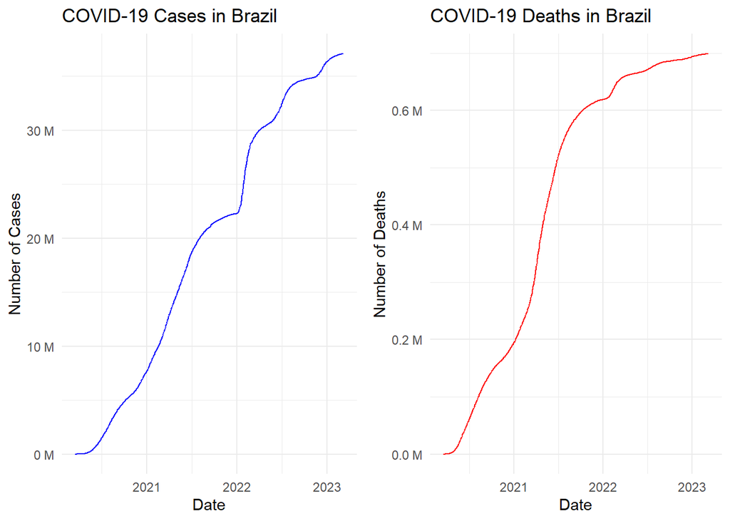

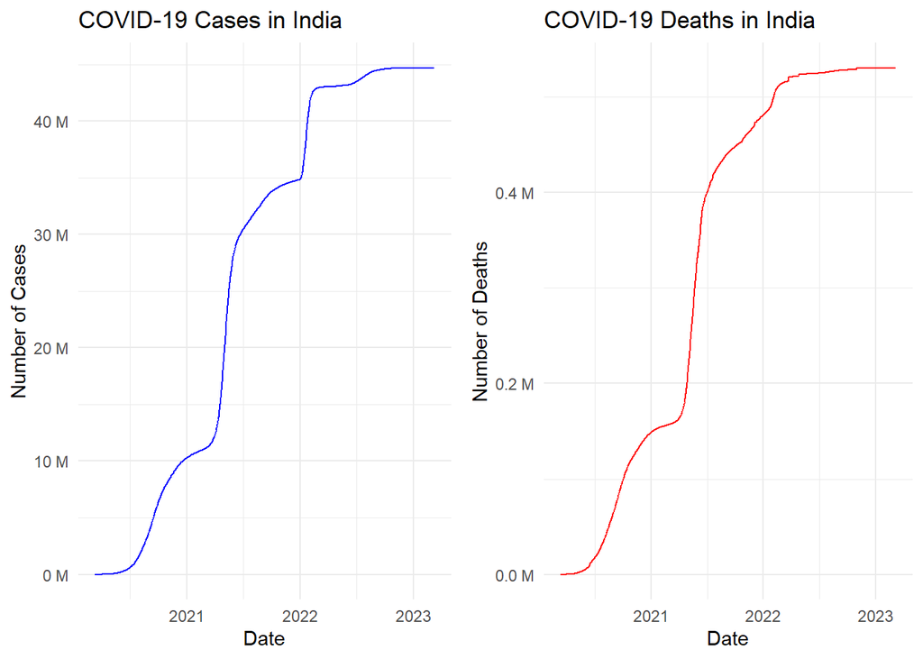

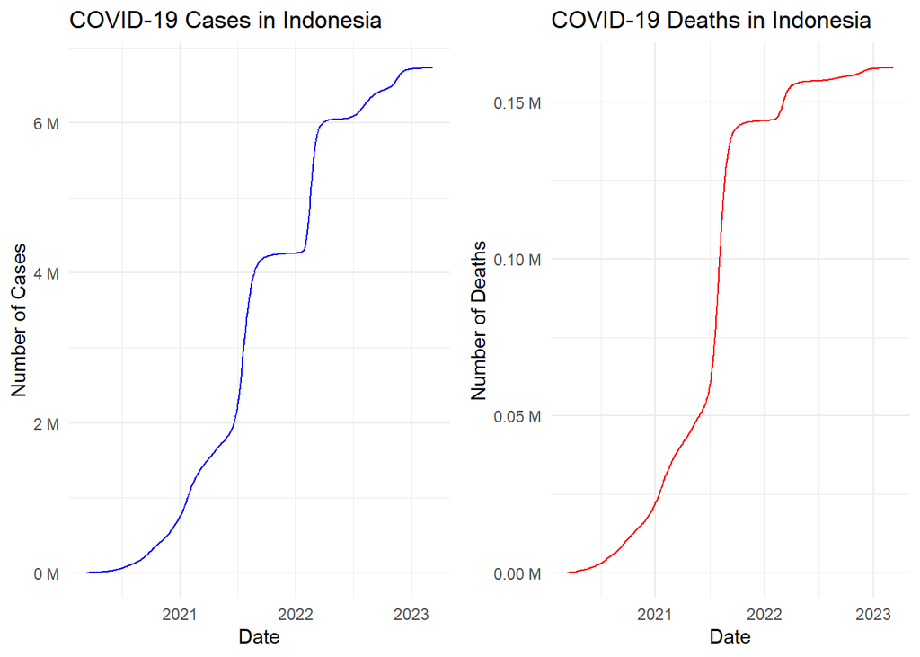

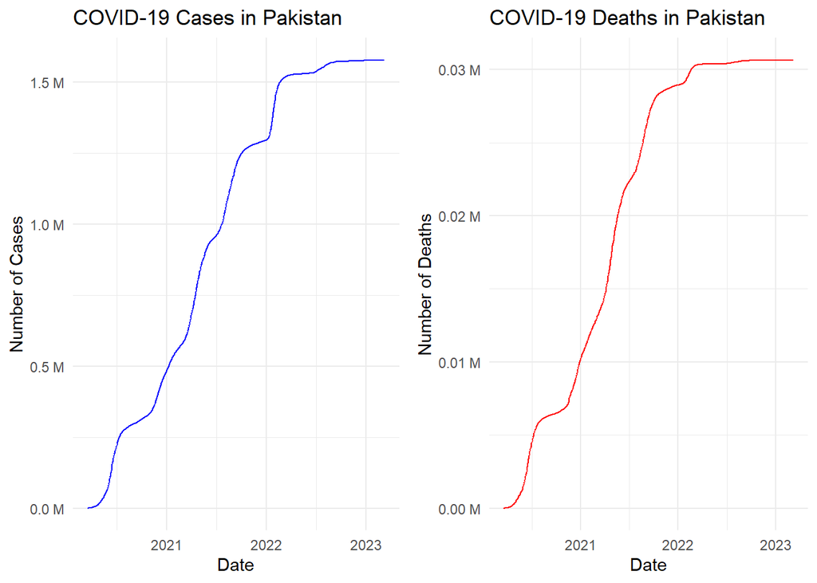

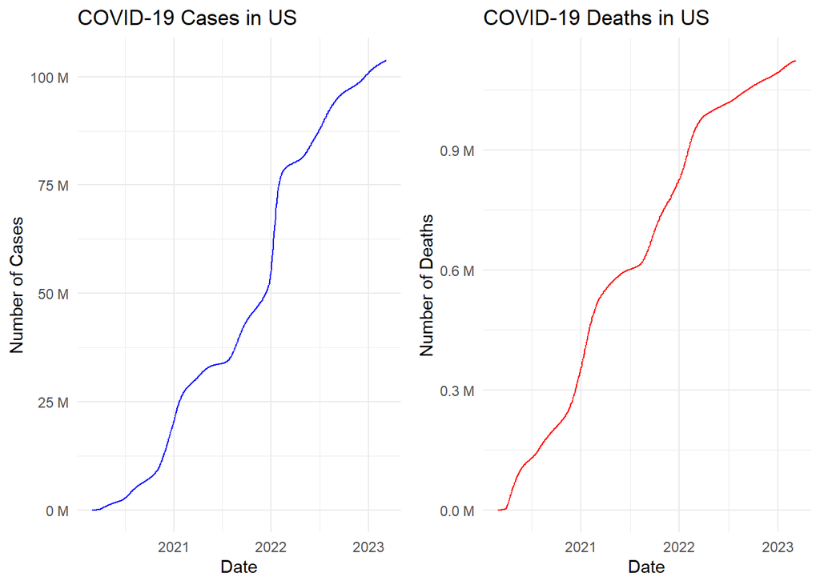

```r
# Create a plot for each country
country_list <- unique(final_data$Countries)

# Loop to create a subplot for each country
for (country in country_list) {
  country_data <- filter(final_data, Countries == country)

  # Create a plot for cases
  cases_plot <- ggplot(country_data, aes(x = date, y = cases)) +
    geom_line(color = "blue") +
    labs(title = paste("COVID-19 Cases in", country),
         x = "Date",
         y = "Number of Cases") +
    theme_minimal() +
    scale_y_continuous(labels = label_number(scale = 1e-6, suffix = " M"))  # Format numbers in millions

  # Create a plot for deaths
  deaths_plot <- ggplot(country_data, aes(x = date, y = deaths)) +
    geom_line(color = "red") +
    labs(title = paste("COVID-19 Deaths in", country),
         x = "Date",
         y = "Number of Deaths") +
    theme_minimal() +
    scale_y_continuous(labels = label_number(scale = 1e-6, suffix = " M"))  # Format numbers in millions

  # Combine the plots side by side
  combined_plot <- grid.arrange(cases_plot, deaths_plot, ncol = 2)

  # Display the combined plot
  invisible(combined_plot)
}
```

Upon analyzing the data, we noticed that it exhibits similar patterns across different countries. Next, we will compare some statistical data from the countries.

```r
# Group the data by country and calculate the required statistics
summary_by_country <- final_data %>%
  group_by(Countries) %>%
  summarise(
    Average_Cases = mean(cases),                     # Average number of cases
    Average_Deaths = mean(deaths),                   # Average number of deaths
    Std_Dev_Cases = sd(cases),                       # Standard deviation of cases
    Std_Dev_Deaths = sd(deaths),                     # Standard deviation of deaths
    Total_Cases = sum(cases),                        # Total number of cases
    Total_Deaths = sum(deaths),                      # Total number of deaths
    First_Death_Date = min(date[deaths > 0]),        # Date of the first death
    First_Case_Date = min(date[cases > 0]),          # Date of the first case
    Last_Death_Date = max(date[deaths > 0]),         # Date of the last death
    Last_Case_Date = max(date[cases > 0])            # Date of the last case
  )

# Display the summary
summary_by_country
```

```
## # A tibble: 5 × 11
##   Countries Average_Cases Average_Deaths Std_Dev_Cases Std_Dev_Deaths
##   <chr>             <dbl>          <dbl>         <dbl>          <dbl>
## 1 Brazil        19469384.        448696.     12508153.        249607.
## 2 India         26628080.        333566.     17119867.        203194.
## 3 Indonesia      3375143.         91715.      2568010.         66054.
## 4 Pakistan        993350.         20505.       552534.         10987.
## 5 US            48699714.        646043.     36017944.        364255.
## # ℹ 6 more variables: Total_Cases <dbl>, Total_Deaths <dbl>,
## #   First_Death_Date <date>, First_Case_Date <date>, Last_Death_Date <date>,
## #   Last_Case_Date <date>
```

Analyzing the statistical summary, we can highlight:

1. **Significant Impact in the US, Brazil, and India**: These countries have the highest numbers of cases and deaths, indicating a substantial impact of the pandemic.
2. **Marked Variability in Cases**: The US, Brazil, and India exhibit high standard deviations for both cases and deaths, reflecting significant fluctuations in daily numbers. These variations could be due to changes in public health policies, availability of testing, and virus transmission dynamics.
3. **Consistency in Event Dates**: The first and last occurrences of cases and deaths are similar across the listed countries, showing that the pandemic reached these countries around March 2020 and remained active until at least March 2023.
4. **Differences in Mortality Rate**: Variations in the mortality rate among countries suggest differences in healthcare systems, the effectiveness of intervention measures, testing rates, and demographic characteristics.

### Model and Assess

For the modeling of COVID-19 data, our goal is to predict cases and deaths for each country. To achieve this, we will adopt the following approach: when predicting the response variable “Deaths,” we will use the variables “Cases” and “Date” as predictors; and when predicting the response variable “Cases,” we will use the variables “Date” and “Deaths” as predictors.

Initially, we conducted tests using time series models and generalized linear models. However, these models showed lower performance than expected compared to Generalized Additive Models (GAM).

We chose to use GAM as an alternative approach for evaluation in this project due to its flexibility in capturing non-linear relationships in the data.

For the sample selection, we initially considered all available data. However, when exploring and modifying the data, we observed that, starting from the second half of 2022, the graphs of cases and deaths show a similar behavior pattern. Both indicators tend to stabilize at lower levels along the Y-axis.

Therefore, we decided to focus on analyzing this specific period, starting from the second half of 2022, to avoid potential biases and obtain more consistent results.

Additional aspects related to possible biases and considerations will be addressed in the project’s conclusion.

```
##
## Processing country: Brazil
```

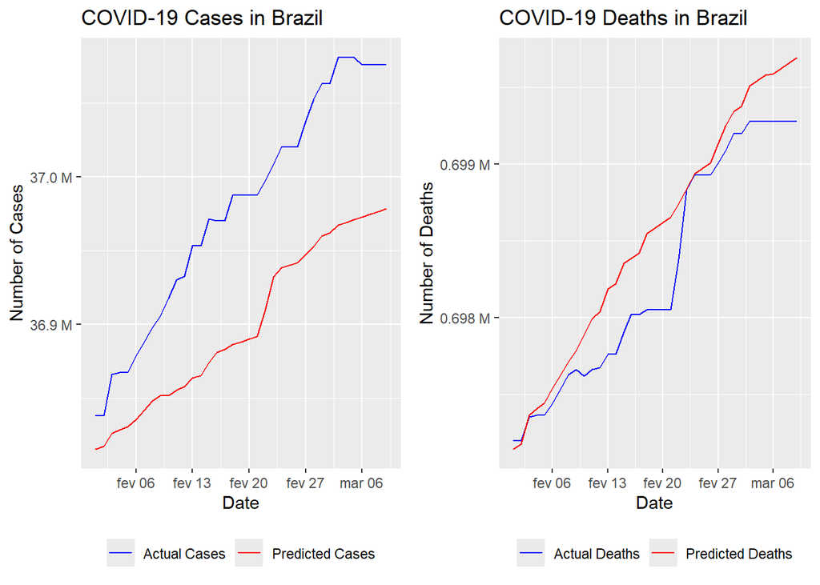

```
##
## Summary of the cases model for Brazil :
##
## Family: gaussian
## Link function: identity
##
## Formula:
## cases ~ c(date) + s(deaths)
##
## Parametric coefficients:
##               Estimate Std. Error  t value Pr(>|t|)
## (Intercept) -905.77165   59.93369   -15.11   <2e-16 ***
## c(date)     1832.69540    0.04636 39535.64   <2e-16 ***
## ---
## Signif. codes:  0 '***' 0.001 '**' 0.01 '*' 0.05 '.' 0.1 ' ' 1
##
## Approximate significance of smooth terms:
##             edf Ref.df     F p-value
## s(deaths) 8.937  8.999 70465  <2e-16 ***
## ---
## Signif. codes:  0 '***' 0.001 '**' 0.01 '*' 0.05 '.' 0.1 ' ' 1
##
## Rank: 10/11
## R-sq.(adj) =      1   Deviance explained =  100%
## GCV = 1.2425e+08  Scale est. = 1.1573e+08  n = 145
##
## Summary of the deaths model for Brazil :
##
## Family: gaussian
## Link function: identity
##
## Formula:
## deaths ~ c(date) + s(cases)
##
## Parametric coefficients:
##               Estimate Std. Error  t value Pr(>|t|)
## (Intercept) -2.158e+01  1.139e+00   -18.94   <2e-16 ***
## c(date)      3.572e+01  3.942e-04 90633.25   <2e-16 ***
## ---
## Signif. codes:  0 '***' 0.001 '**' 0.01 '*' 0.05 '.' 0.1 ' ' 1
##
## Approximate significance of smooth terms:
##            edf Ref.df    F p-value
## s(cases) 8.644  8.964 9185  <2e-16 ***
## ---
## Signif. codes:  0 '***' 0.001 '**' 0.01 '*' 0.05 '.' 0.1 ' ' 1
##
## Rank: 10/11
## R-sq.(adj) =  0.999   Deviance explained = 99.9%
## GCV = 8802.5  Scale est. = 8217      n = 145
##
## Processing country: India
```

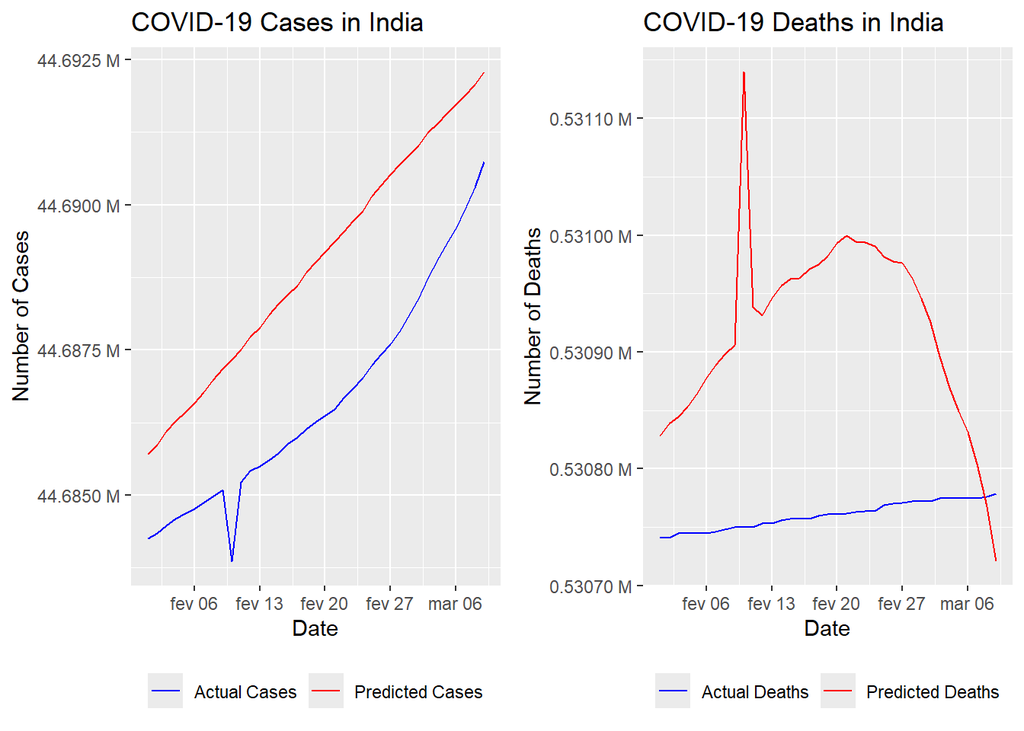

```
##
## Summary of the cases model for India :
##
## Family: gaussian
## Link function: identity
##
## Formula:
## cases ~ c(date) + s(deaths)
##
## Parametric coefficients:
##              Estimate Std. Error t value Pr(>|t|)
## (Intercept) 4.154e+07  4.380e+05  94.847  < 2e-16 ***
## c(date)     1.606e+02  2.268e+01   7.084 6.54e-11 ***
## ---
## Signif. codes:  0 '***' 0.001 '**' 0.01 '*' 0.05 '.' 0.1 ' ' 1
##
## Approximate significance of smooth terms:
##            edf Ref.df    F p-value
## s(deaths) 4.86  5.841 7299  <2e-16 ***
## ---
## Signif. codes:  0 '***' 0.001 '**' 0.01 '*' 0.05 '.' 0.1 ' ' 1
##
## R-sq.(adj) =  0.999   Deviance explained = 99.9%
## GCV = 2.4231e+06  Scale est. = 2.3085e+06  n = 145
##
## Summary of the deaths model for India :
##
## Family: gaussian
## Link function: identity
##
## Formula:
## deaths ~ c(date) + s(cases)
##
## Parametric coefficients:
##              Estimate Std. Error  t value Pr(>|t|)
## (Intercept) 2.986e+02  2.184e+01    13.67   <2e-16 ***
## c(date)     2.742e+01  1.304e-03 21033.23   <2e-16 ***
## ---
## Signif. codes:  0 '***' 0.001 '**' 0.01 '*' 0.05 '.' 0.1 ' ' 1
##
## Approximate significance of smooth terms:
##            edf Ref.df     F p-value
## s(cases) 8.864  8.994 181.3  <2e-16 ***
## ---
## Signif. codes:  0 '***' 0.001 '**' 0.01 '*' 0.05 '.' 0.1 ' ' 1
##
## Rank: 10/11
## R-sq.(adj) =  0.976   Deviance explained = 97.7%
## GCV =  24455  Scale est. = 22791     n = 145
##
## Processing country: Indonesia
```

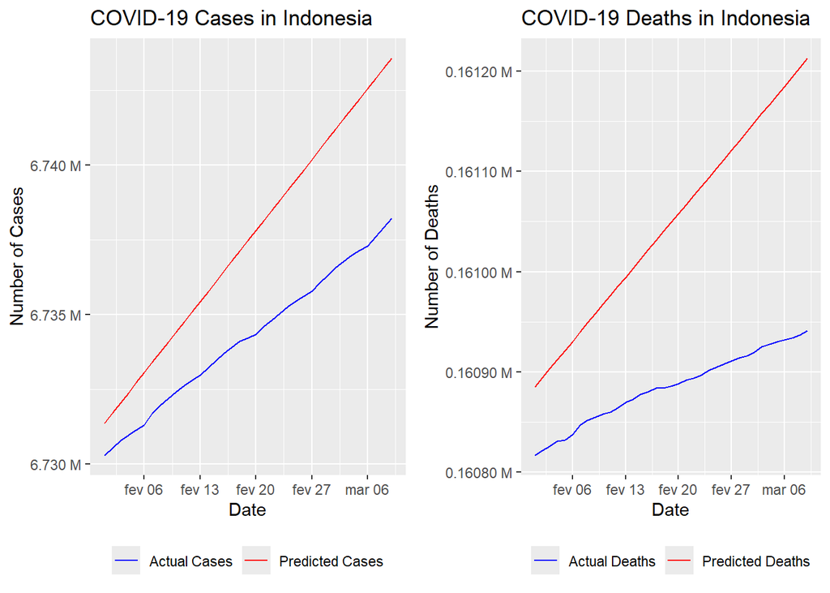

```
##
## Summary of the cases model for Indonesia :
##
## Family: gaussian
## Link function: identity
##
## Formula:
## cases ~ c(date) + s(deaths)
##
## Parametric coefficients:
##              Estimate Std. Error  t value Pr(>|t|)
## (Intercept) 6.967e+02  4.237e+01    16.44   <2e-16 ***
## c(date)     3.409e+02  4.309e-03 79124.04   <2e-16 ***
## ---
## Signif. codes:  0 '***' 0.001 '**' 0.01 '*' 0.05 '.' 0.1 ' ' 1
##
## Approximate significance of smooth terms:
##             edf Ref.df      F p-value
## s(deaths) 8.852  8.993 273143  <2e-16 ***
## ---
## Signif. codes:  0 '***' 0.001 '**' 0.01 '*' 0.05 '.' 0.1 ' ' 1
##
## Rank: 10/11
## R-sq.(adj) =      1   Deviance explained =  100%
## GCV = 7.9849e+05  Scale est. = 7.4424e+05  n = 145
##
## Summary of the deaths model for Indonesia :
##
## Family: gaussian
## Link function: identity
##
## Formula:
## deaths ~ c(date) + s(cases)
##
## Parametric coefficients:
##              Estimate Std. Error   t value Pr(>|t|)
## (Intercept) 4.4513329  1.9890174     2.238   0.0269 *
## c(date)     8.2516078  0.0001327 62180.317   <2e-16 ***
## ---
## Signif. codes:  0 '***' 0.001 '**' 0.01 '*' 0.05 '.' 0.1 ' ' 1
##
## Approximate significance of smooth terms:
##            edf Ref.df     F p-value
## s(cases) 8.876  8.995 23965  <2e-16 ***
## ---
## Signif. codes:  0 '***' 0.001 '**' 0.01 '*' 0.05 '.' 0.1 ' ' 1
##
## Rank: 10/11
## R-sq.(adj) =      1   Deviance explained =  100%
## GCV = 407.06  Scale est. = 379.33    n = 145
##
## Processing country: Pakistan
```

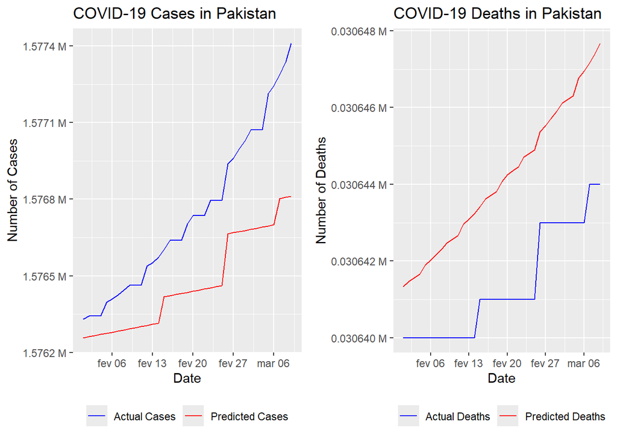

```
##
## Summary of the cases model for Pakistan :
##
## Family: gaussian
## Link function: identity
##
## Formula:
## cases ~ c(date) + s(deaths)
##
## Parametric coefficients:
##              Estimate Std. Error t value Pr(>|t|)
## (Intercept) 1.490e+06  3.213e+04  46.373  < 2e-16 ***
## c(date)     4.377e+00  1.663e+00   2.632  0.00945 **
## ---
## Signif. codes:  0 '***' 0.001 '**' 0.01 '*' 0.05 '.' 0.1 ' ' 1
##
## Approximate significance of smooth terms:
##             edf Ref.df     F p-value
## s(deaths) 3.202  4.126 377.1  <2e-16 ***
## ---
## Signif. codes:  0 '***' 0.001 '**' 0.01 '*' 0.05 '.' 0.1 ' ' 1
##
## R-sq.(adj) =  0.995   Deviance explained = 99.5%
## GCV =  12862  Scale est. = 12401     n = 145
##
## Summary of the deaths model for Pakistan :
##
## Family: gaussian
## Link function: identity
##
## Formula:
## deaths ~ c(date) + s(cases)
##
## Parametric coefficients:
##              Estimate Std. Error t value Pr(>|t|)
## (Intercept) 2.873e+04  2.434e+02 118.044  < 2e-16 ***
## c(date)     9.802e-02  1.260e-02   7.779 1.44e-12 ***
## ---
## Signif. codes:  0 '***' 0.001 '**' 0.01 '*' 0.05 '.' 0.1 ' ' 1
##
## Approximate significance of smooth terms:
##            edf Ref.df     F p-value
## s(cases) 2.814  3.595 562.1  <2e-16 ***
## ---
## Signif. codes:  0 '***' 0.001 '**' 0.01 '*' 0.05 '.' 0.1 ' ' 1
##
## R-sq.(adj) =  0.994   Deviance explained = 99.4%
## GCV = 0.73634  Scale est. = 0.7119    n = 145
##
## Processing country: US
```

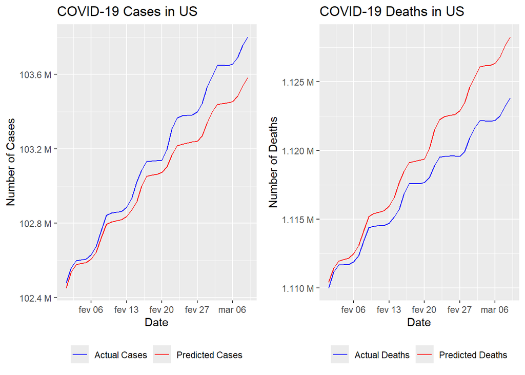

```
##
## Summary of the cases model for US :
##
## Family: gaussian
## Link function: identity
##
## Formula:
## cases ~ c(date) + s(deaths)
##
## Parametric coefficients:
##               Estimate Std. Error t value Pr(>|t|)
## (Intercept) -2817.6601    57.0343   -49.4   <2e-16 ***
## c(date)      5107.3573     0.0851 60017.3   <2e-16 ***
## ---
## Signif. codes:  0 '***' 0.001 '**' 0.01 '*' 0.05 '.' 0.1 ' ' 1
##
## Approximate significance of smooth terms:
##             edf Ref.df      F p-value
## s(deaths) 8.769  8.984 146282  <2e-16 ***
## ---
## Signif. codes:  0 '***' 0.001 '**' 0.01 '*' 0.05 '.' 0.1 ' ' 1
##
## Rank: 10/11
## R-sq.(adj) =      1   Deviance explained =  100%
## GCV = 4.1958e+08  Scale est. = 3.9131e+08  n = 145
##
## Summary of the deaths model for US :
##
## Family: gaussian
## Link function: identity
##
## Formula:
## deaths ~ c(date) + s(cases)
##
## Parametric coefficients:
##               Estimate Std. Error  t value Pr(>|t|)
## (Intercept) -1.009e+02  2.319e+00   -43.49   <2e-16 ***
## c(date)      5.582e+01  8.024e-04 69563.31   <2e-16 ***
## ---
## Signif. codes:  0 '***' 0.001 '**' 0.01 '*' 0.05 '.' 0.1 ' ' 1
##
## Approximate significance of smooth terms:
##            edf Ref.df     F p-value
## s(cases) 8.777  8.985 91605  <2e-16 ***
## ---
## Signif. codes:  0 '***' 0.001 '**' 0.01 '*' 0.05 '.' 0.1 ' ' 1
##
## Rank: 10/11
## R-sq.(adj) =      1   Deviance explained =  100%
## GCV =  36514  Scale est. = 34052     n = 145
```

```r
# Filter the data for the last six months
final_data_6months <- final_data %>%
  filter(date >= (max(date) - months(6)))

# Get the list of countries
countries <- unique(final_data_6months$Countries)

# Loop to process each country
for (country in countries) {
  cat("\nProcessing country:", country, "\n")

  # Filter the data for the current country
  country_data <- final_data_6months %>%
    filter(Countries == country) %>%
    arrange(date)

  # Determine the split point for 80% training and 20% testing
  split_point <- floor(0.8 * nrow(country_data))

  # Split the data into training (80%) and testing (20%) sets
  train_indices <- country_data[1:split_point, ]
  test_indices <- country_data[(split_point + 1):nrow(country_data), ]

  # Create a GAM model for COVID-19 cases using the training set
  gam_cases <- gam(cases ~ c(date) + s(deaths), family = gaussian(), data = train_indices)

  # Create a GAM model for COVID-19 deaths using the training set
  gam_deaths <- gam(deaths ~ c(date) + s(cases), family = gaussian(), data = train_indices)

  # Plot the results for cases in the test set
  plot_cases <- ggplot(test_indices, aes(x = date)) +
    geom_line(aes(y = cases, color = "Actual Cases")) +
    geom_line(aes(y = predict(gam_cases, newdata = test_indices), color = "Predicted Cases")) +
    labs(title = paste("COVID-19 Cases in", country), x = "Date", y = "Number of Cases") +
    scale_y_continuous(labels = scales::unit_format(unit = "M", scale = 1e-6)) +
    scale_color_manual(values = c("Actual Cases" = "blue", "Predicted Cases" = "red")) +
    theme(legend.title = element_blank(), legend.position = "bottom")

  # Plot the results for deaths in the test set
  plot_deaths <- ggplot(test_indices, aes(x = date)) +
    geom_line(aes(y = deaths, color = "Actual Deaths")) +
    geom_line(aes(y = predict(gam_deaths, newdata = test_indices), color = "Predicted Deaths")) +
    labs(title = paste("COVID-19 Deaths in", country), x = "Date", y = "Number of Deaths") +
    scale_y_continuous(labels = scales::unit_format(unit = "M", scale = 1e-6)) +
    scale_color_manual(values = c("Actual Deaths" = "blue", "Predicted Deaths" = "red")) +
    theme(legend.title = element_blank(), legend.position = "bottom")

  # Arrange the plots side by side
  grid.arrange(plot_cases, plot_deaths, ncol = 2)

  # Print the summary of the cases model
  cat("\nSummary of the cases model for", country, ":\n")
  print(summary(gam_cases))

  # Print the summary of the deaths model
  cat("\nSummary of the deaths model for", country, ":\n")
  print(summary(gam_deaths))
}
```

Finally, with respect to the assessment, we highlight the following aspects:

##### Cases Model:

- **Fit**: Excellent, with an extremely high adjusted R².
- **Possible Overfitting**: The very high adjusted R² value may indicate overfitting.
- **Smooth Terms**: Highly significant, capturing complex relationships that are not explained by linear terms alone.

##### Deaths Model:

- **Fit**: Excellent, with an adjusted R² close to 1.
- **Smooth Terms**: Significant, reflecting complexities in the interactions between deaths and cases over time.

### Conclusion

Analyzing the impacts of COVID-19 remains a significant challenge even today, as the effects of the pandemic have dissipated due to vaccines and other treatments that were unknown at the time.

Specifically regarding the dataset, it is evident that the scientific community, governments, industries, and even some activists have sought to understand and predict these impacts through mathematical models during this period. However, in my research, no model has adequately captured the global variations, leading to the realization that many aspects remain unexplained and there is a need for further development in the field.

It is also a fact that the COVID-19 pandemic prompted discussions in international organizations, economic forums, and other venues. It cannot be ruled out that some states may have masked the true impacts by smoothing the data or imposing restrictions on the official release of data, following protocols established by their respective health authorities. This introduces a bias that directly affects evaluations.

Another aspect to consider is the distribution and access to vaccines. There was a large supply of vaccines in 2022, which may have yielded different results, or the mutation of the COVID-19 virus could have altered its characteristics, leading to milder clinical cases and fewer deaths.

Additionally, the dataset has limited variables. Including more variables such as the percentage of deaths related to age, race, sex, and other characteristics could potentially improve the accuracy and significance of the models.

However, given the randomness associated with a highly contagious virus, it might not fully address the variations.

In conclusion, it is essential to reflect on what COVID-19 has brought to the data community, research, and businesses. The world is indeed very different after COVID-19. The pandemic has highlighted the importance of accurate data, robust modeling, and the need for ongoing improvement in our understanding and response to global health crises.